# Annotation of escapee CpGs

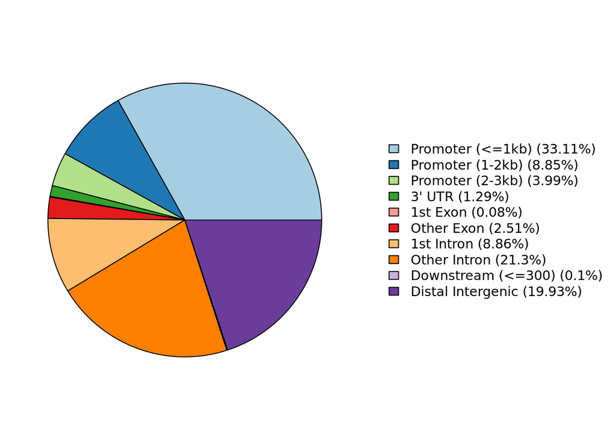

```r
ChIPseeker::plotAnnoPie(EscapeeAnno)
```

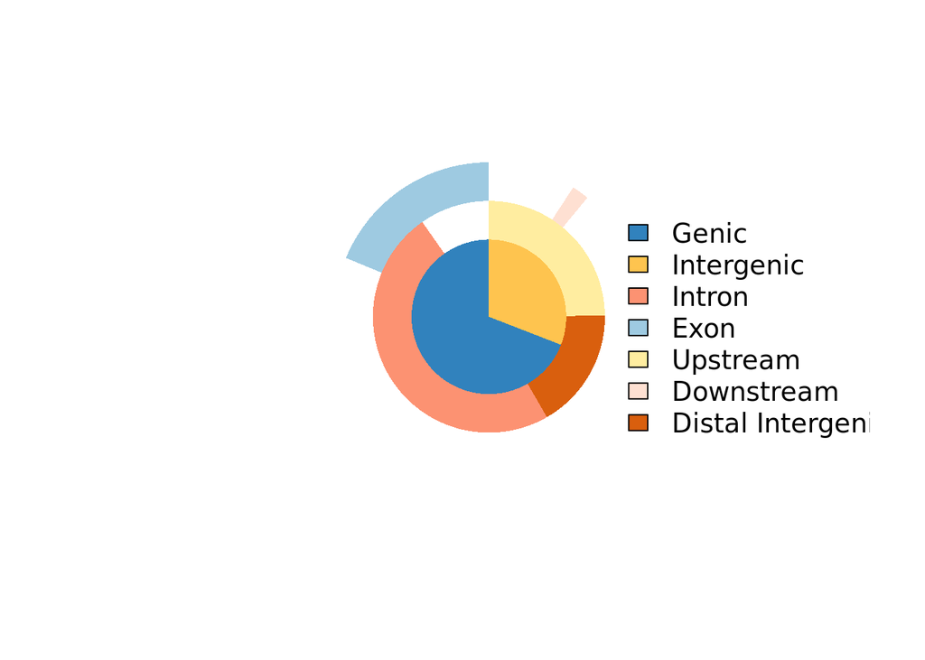

```r
ChIPseeker::vennpie(EscapeeAnno)
```

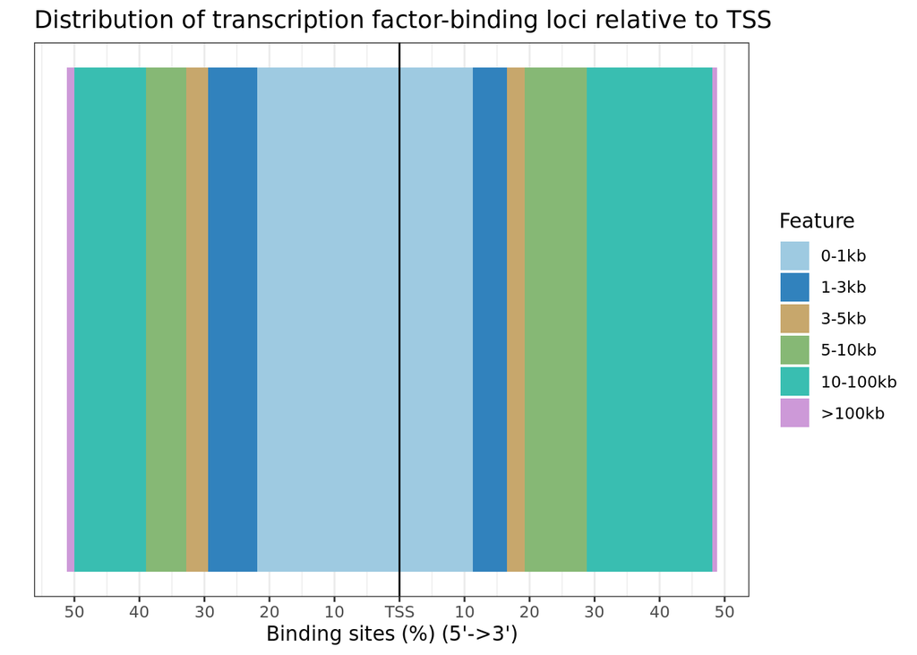

```r
ChIPseeker::plotDistToTSS(EscapeeAnno)
```

**From ensembl ids to gene symbols, entrez ids and metadata**

```r
Host <- "https://aug2020.archive.ensembl.org"
Specie <- "hsapiens"
BioMart <- biomaRt::listMarts(host=Host)[1,1]
Version <- biomaRt::listMarts(host=Host)[1,2]
Mart <- biomaRt::useMart(host=Host, biomart=BioMart, version=Version,
                         dataset=paste0(Specie,'_gene_ensembl'))

EscapeeGenes_ensembl = unique(as.data.frame(EscapeeAnno)$geneId) #Genes assigned to the escapees regions by chipseeker

Attributes = c("ensembl_gene_id_version", "ensembl_gene_id", "hgnc_symbol", "gene_biotype")

EscapeeGeneAnnotation <- biomaRt::getBM(mart=Mart, filters='ensembl_gene_id_version', values=EscapeeGenes_ensembl, attributes=Attributes, uniqueRows=TRUE)
EscapeeGeneAnnotation <- EscapeeGeneAnnotation %>% dplyr::distinct() #%>%filter(!is.na(hgnc_symbol)) %>% filter(!hgnc_symbol%in%"")
```

```r
EscapeeGenes_ensembl[!EscapeeGenes_ensembl %in% EscapeeGeneAnnotation$ensembl_gene_id_version] %>% head() #ChipSeeker annotation that are not present in the biomart
## character(0)

EscapeeGenes_symbol = EscapeeGeneAnnotation %>% filter(!is.na(hgnc_symbol)) %>% filter(!hgnc_symbol%in%"") %>% pull(hgnc_symbol) %>% unique()

EscapeeGenes_entrez = mapIds(org.Hs.eg.db, keys = EscapeeGenes_symbol, column = "ENTREZID", keytype = "SYMBOL") %>% unique()
## 'select()' returned 1:1 mapping between keys and columns
```

```r
AnnotatedEscapees <- dplyr::left_join(as.data.frame(EscapeeAnno), EscapeeGeneAnnotation, by=c('geneId' = 'ensembl_gene_id_version'))
```

# 4. Functional enrichment analysis

## 4.1 Selection of modulated genes and generation of gene vector

```r
GeneVectors <- topGOGeneVectors_meth_v2(gene_symbols = EscapeeGenes_symbol, genomic_type = "all", gene_type = "all", Universe = GeneUniverse_symbol) %>% unlist()
## [1] "All genomic regions and gene types will be kept"
## [1] "There are some genes symbols which are not in the gene universe! They will not be considered..."
```

Genes associated to escapee CpGs that are not present in the universe:

```r
not_present <- EscapeeGeneAnnotation %>% filter(hgnc_symbol %in% unique(na.omit(EscapeeGenes_symbol))[!unique(na.omit(EscapeeGenes_symbol)) %in%  GeneUniverse_symbol])
not_present
```

```
##   ensembl_gene_id_version ensembl_gene_id hgnc_symbol gene_biotype
## 1       ENSG00000278970.2 ENSG00000278970        HEIH       lncRNA
```

These are the CpGs annotated with those genes

```r
EscapeeAnno@anno %>% as.data.frame() %>% filter(geneId %in% not_present$ensembl_gene_id_version)
##   seqnames     start       end width strand       annotation geneChr geneStart
## 1     chr5 180830679 180830679     1      * Promoter (<=1kb)       5 180826871
## 2     chr5 180830691 180830691     1      * Promoter (<=1kb)       5 180826871
## 3     chr5 180830697 180830697     1      * Promoter (<=1kb)       5 180826871
## 4     chr5 180830795 180830795     1      * Promoter (<=1kb)       5 180826871
## 5     chr5 180830797 180830797     1      * Promoter (<=1kb)       5 180826871
##     geneEnd geneLength geneStrand            geneId      transcriptId
## 1 180830659       3789          2 ENSG00000278970.2 ENST00000651563.1
## 2 180830659       3789          2 ENSG00000278970.2 ENST00000651563.1
## 3 180830659       3789          2 ENSG00000278970.2 ENST00000651563.1
## 4 180830659       3789          2 ENSG00000278970.2 ENST00000651563.1
## 5 180830659       3789          2 ENSG00000278970.2 ENST00000651563.1
##   distanceToTSS
## 1           -20
## 2           -32
## 3           -38
## 4          -136
## 5          -138
```

```r
BpEval <- ifelse(length(grep('BP', params$TopGO))!=0, TRUE, FALSE)
MfEval <- ifelse(length(grep('MF', params$TopGO))!=0, TRUE, FALSE)
CcEval <- ifelse(length(grep('CC', params$TopGO))!=0, TRUE, FALSE)
```

Therefore:

- universe genes: **36011** genes
- escapee genes: **998** genes

## 4.2 TopGO analysis: Biological Process

On the basis of the analysis settings, the enrichment for Biological Process **IS performed**.

```r
# I generate a list that contains the association between each gene and the GO terms that are associated to it
BPann <- topGO::annFUN.org(whichOnto="BP", feasibleGenes=names(GeneVectors),
                           mapping="org.Hs.eg.db", ID="symbol") %>% inverseList()

# Wrapper function for topGO analysis
ResBPAll <- topGOResults_new(Genes=GeneVectors, gene2GO=BPann, ontology='BP',
                         desc=NULL, nodeSize=15, algorithm='weight01', statistic='fisher',
                         EnTh=params$GoEnTh, PvalTh=params$GoPvalTh, minTerms=12, geneTh=4,
                         saveRes=TRUE, outDir=paste0(OutputFolder), fileName='BPAll', maxAnn = 500)
## Gene vector contains levels: 0,1
##
## Building most specific GOs .....
##  ( 12544 GO terms found. )
##
## Build GO DAG topology ..........
##  ( 15945 GO terms and 36197 relations. )
##
## Annotating nodes ...............
##  ( 18089 genes annotated to the GO terms. )
##
##           -- Weight01 Algorithm --
##
##       the algorithm is scoring 4389 nontrivial nodes
##       parameters:
##           test statistic: fisher
##
##   Level 18:  2 nodes to be scored    (0 eliminated genes)
##
##   Level 17:  4 nodes to be scored    (0 eliminated genes)
##
##   Level 16:  9 nodes to be scored    (45 eliminated genes)
##
##   Level 15:  20 nodes to be scored   (101 eliminated genes)
##
##   Level 14:  43 nodes to be scored   (264 eliminated genes)
##
##   Level 13:  75 nodes to be scored   (581 eliminated genes)
##
##   Level 12:  136 nodes to be scored  (1490 eliminated genes)
##
##   Level 11:  287 nodes to be scored  (3905 eliminated genes)
##
##   Level 10:  471 nodes to be scored  (6200 eliminated genes)
##
##   Level 9:   621 nodes to be scored  (8164 eliminated genes)
##
##   Level 8:   673 nodes to be scored  (10914 eliminated genes)
##
##   Level 7:   721 nodes to be scored  (13268 eliminated genes)
##
##   Level 6:   619 nodes to be scored  (15490 eliminated genes)
##
##   Level 5:   383 nodes to be scored  (16686 eliminated genes)
##
##   Level 4:   216 nodes to be scored  (17396 eliminated genes)
##
##   Level 3:   90 nodes to be scored   (17691 eliminated genes)
##
##   Level 2:   18 nodes to be scored   (17829 eliminated genes)
##
##   Level 1:   1 nodes to be scored    (17896 eliminated genes)
```

### **Result visualization: Barplot**

```r
nterms=20
cols <- c(All='forestgreen', Down='blue', Up='red')
pals <- lapply(cols, {function(el) grDevices::colorRampPalette(c('gold', el))(nterms)})
```

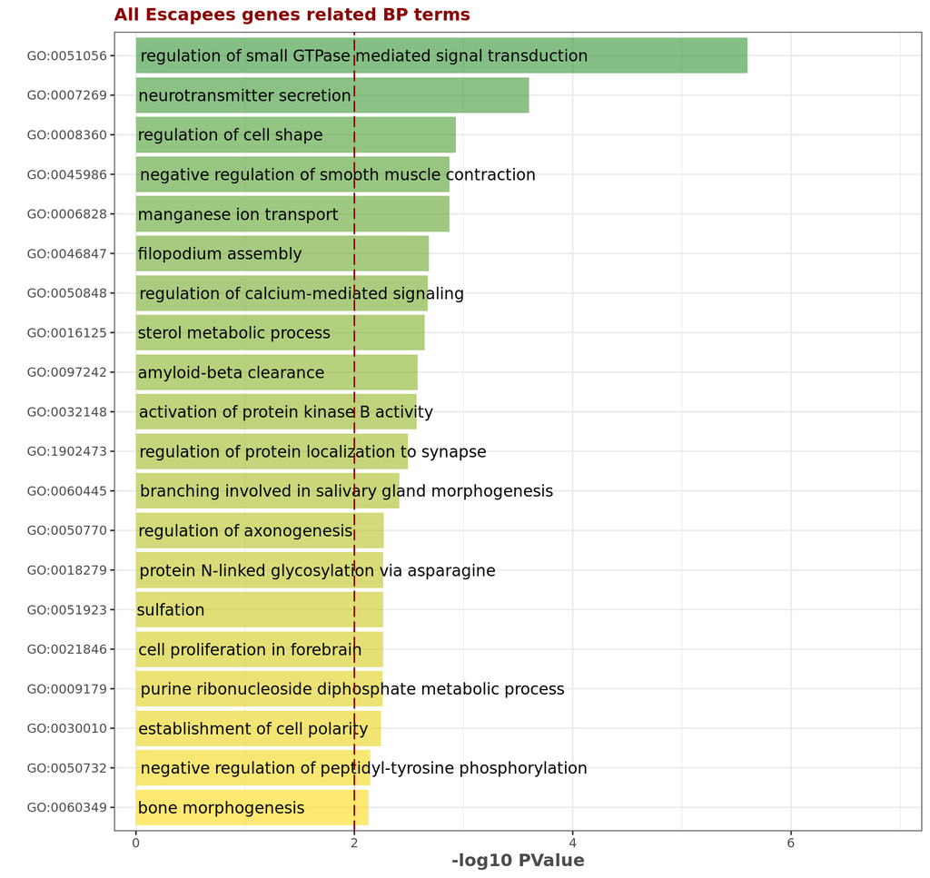

```r
if(nrow(ResBPAll$ResSel)>0){
  topGOBarplot_new(TopGORes=ResBPAll$ResSel, terms=nterms, pvalTh=0.01, plotTitle=paste0("All Escapees genes related BP terms"),
                             palette=pals$All, flip_x=FALSE)
}
```

### **Result visualization: Bubbleplot**

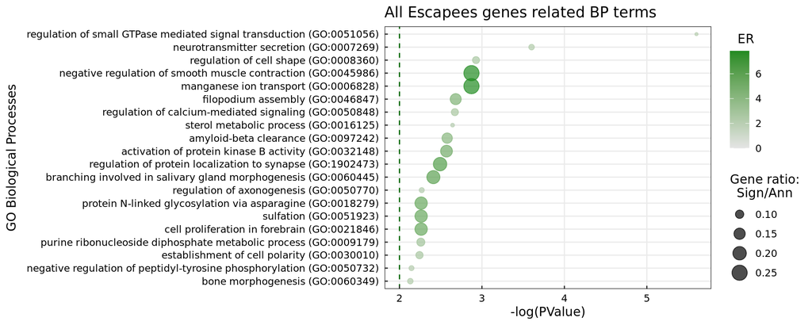

```r
if(nrow(ResBPAll$ResSel)>0){
  bubbleplot(ResBPAll$ResSel, terms=nterms, Ont = "BP", pvalTh=0.01, plotTitle="All Escapees genes related BP terms")
  }
## Warning: Using `size` aesthetic for lines was deprecated in ggplot2 3.4.0.
## ℹ Please use `linewidth` instead.
## This warning is displayed once every 8 hours.
## Call `lifecycle::last_lifecycle_warnings()` to see where this warning was
## generated.
```

### **Result visualization: table of genes in top terms**

```r
if(nrow(ResBPAll$ResSel)>0){
  table_GenesInTerm_BPAll <- TableGenesInTerm(ResBPAll$ResSel, ResBPAll$GOdata, nterms=nterms)
}

table_GenesInTerm_BPAll %>% dplyr::select(-c(Score, GOid)) %>%
    datatable(class = 'hover', rownames = FALSE, extension='Buttons', escape = FALSE, caption = paste0("All genes in top ", nterms, " BP terms"), options = list(pageLength=10, dom='Bfrtip', autoWidth=TRUE, buttons=list(c('csv', 'excel'))))
```

| Gene | GOterm |
| --- | --- |
| ARHGAP12 | regulation of small GTPase mediated signal transduction (GO:0051056) |
| ARHGAP21 | regulation of small GTPase mediated signal transduction (GO:0051056) |
| ARHGAP39 | regulation of small GTPase mediated signal transduction (GO:0051056) |
| ARHGAP5 | regulation of small GTPase mediated signal transduction (GO:0051056) |
| ARHGEF10L | regulation of small GTPase mediated signal transduction (GO:0051056) |
| ARHGEF12 | regulation of small GTPase mediated signal transduction (GO:0051056) |
| ARHGEF28 | regulation of small GTPase mediated signal transduction (GO:0051056) |
| ARHGEF4 | regulation of small GTPase mediated signal transduction (GO:0051056) |
| FGD3 | regulation of small GTPase mediated signal transduction (GO:0051056) |
| FGD4 | regulation of small GTPase mediated signal transduction (GO:0051056) |

[output cut: 144 more lines]

## 4.3 TopGO analysis: Molecular Function

On the basis of the analysis settings, the enrichment for Molecular Function **IS performed**.

```r
# I generate a list that contains the association between each gene and the GO terms that are associated to it
MFann <- topGO::annFUN.org(whichOnto="MF", feasibleGenes=names(GeneVectors),
                           mapping="org.Hs.eg.db", ID="symbol") %>% inverseList()

# Wrapper function for topGO analysis
ResMFAll <- topGOResults_new(Genes=GeneVectors, gene2GO=MFann, ontology='MF',
                         desc=NULL, nodeSize=15, algorithm='weight01', statistic='fisher',
                         EnTh=params$GoEnTh, PvalTh=params$GoPvalTh, minTerms=12, geneTh=4,
                         saveRes=TRUE, outDir=paste0(OutputFolder), fileName='MFAll', maxAnn = 500)
## Gene vector contains levels: 0,1
##
## Building most specific GOs .....
##  ( 4502 GO terms found. )
##
## Build GO DAG topology ..........
##  ( 4948 GO terms and 6418 relations. )
##
## Annotating nodes ...............
##  ( 17822 genes annotated to the GO terms. )
##
##           -- Weight01 Algorithm --
##
##       the algorithm is scoring 760 nontrivial nodes
##       parameters:
##           test statistic: fisher
##
##   Level 11:  7 nodes to be scored    (0 eliminated genes)
##
##   Level 10:  12 nodes to be scored   (0 eliminated genes)
##
##   Level 9:   34 nodes to be scored   (205 eliminated genes)
##
##   Level 8:   60 nodes to be scored   (1511 eliminated genes)
##
##   Level 7:   98 nodes to be scored   (3866 eliminated genes)
##
##   Level 6:   147 nodes to be scored  (4653 eliminated genes)
##
##   Level 5:   174 nodes to be scored  (6715 eliminated genes)
##
##   Level 4:   160 nodes to be scored  (10721 eliminated genes)
##
##   Level 3:   51 nodes to be scored   (13969 eliminated genes)
##
##   Level 2:   16 nodes to be scored   (15191 eliminated genes)
##
##   Level 1:   1 nodes to be scored    (17628 eliminated genes)
```

### **Result visualization: Barplot**

```r
nterms=20
cols <- c(All='forestgreen', Down='blue', Up='red')
pals <- lapply(cols, {function(el) grDevices::colorRampPalette(c('gold', el))(nterms)})
```

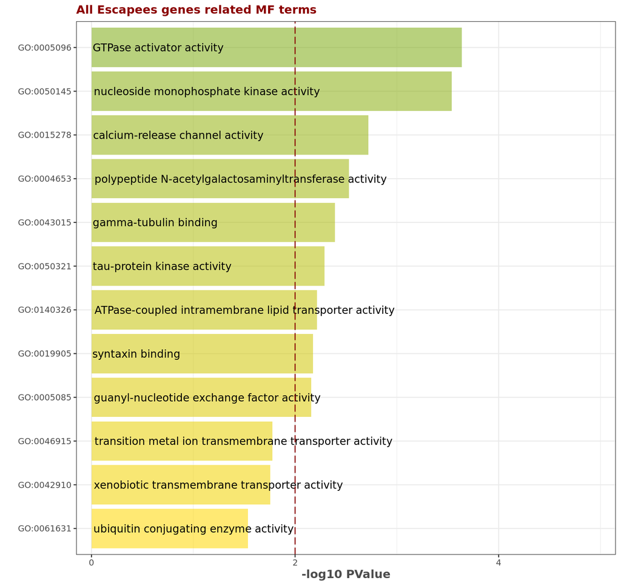

```r
if(nrow(ResMFAll$ResSel)>0){
  topGOBarplot_new(TopGORes=ResMFAll$ResSel, terms=nterms, pvalTh=0.01, plotTitle=paste0("All Escapees genes related MF terms"),
                             palette=pals$All, flip_x=FALSE)
}
```

### **Result visualization: Bubbleplot**

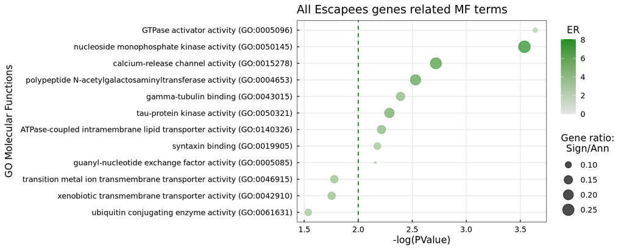

```r
if(nrow(ResMFAll$ResSel)>0){
  bubbleplot(ResMFAll$ResSel, terms=nterms, Ont = "MF", pvalTh=0.01, plotTitle="All Escapees genes related MF terms")
  }
```

### **Result visualization: table of genes in top terms**

```r
if(nrow(ResMFAll$ResSel)>0){
  table_GenesInTerm_MFAll <- TableGenesInTerm(ResMFAll$ResSel, ResMFAll$GOdata, nterms=nterms)
}

table_GenesInTerm_MFAll %>% dplyr::select(-c(Score, GOid)) %>%
    datatable(class = 'hover', rownames = FALSE, extension='Buttons', escape = FALSE, caption = paste0("All genes in top ", nterms, " MF terms"), options = list(pageLength=10, dom='Bfrtip', autoWidth=TRUE, buttons=list(c('csv', 'excel'))))
```

| Gene | GOterm |
| --- | --- |
| AGAP1 | GTPase activator activity (GO:0005096) |
| ARHGAP12 | GTPase activator activity (GO:0005096) |
| ARHGAP21 | GTPase activator activity (GO:0005096) |
| ARHGAP39 | GTPase activator activity (GO:0005096) |
| ARHGAP5 | GTPase activator activity (GO:0005096) |
| ARHGEF10L | GTPase activator activity (GO:0005096) |
| ARHGEF12 | GTPase activator activity (GO:0005096) |
| DEPDC1B | GTPase activator activity (GO:0005096) |
| DOCK4 | GTPase activator activity (GO:0005096) |
| NRP1 | GTPase activator activity (GO:0005096) |

[output cut: 73 more lines]

## 4.4 TopGO analysis: Cellular Component

On the basis of the analysis settings, the enrichment for Cellular Component **IS** performed.

```r
# I generate a list that contains the association between each gene and the GO terms that are associated to it
CCann <- topGO::annFUN.org(whichOnto="CC", feasibleGenes=names(GeneVectors),
                           mapping="org.Hs.eg.db", ID="symbol") %>% inverseList()

# Wrapper function for topGO analysis
ResCCAll <- topGOResults_new(Genes=GeneVectors, gene2GO=CCann, ontology='CC',
                         desc=NULL, nodeSize=15, algorithm='weight01', statistic='fisher',
                         EnTh=params$GoEnTh, PvalTh=params$GoPvalTh, minTerms=12, geneTh=4,
                         saveRes=TRUE, outDir=paste0(OutputFolder), fileName='CCAll', maxAnn = 500)
## Gene vector contains levels: 0,1
##
## Building most specific GOs .....
##  ( 1828 GO terms found. )
##
## Build GO DAG topology ..........
##  ( 2020 GO terms and 3396 relations. )
##
## Annotating nodes ...............
##  ( 18985 genes annotated to the GO terms. )
##
##           -- Weight01 Algorithm --
##
##       the algorithm is scoring 541 nontrivial nodes
##       parameters:
##           test statistic: fisher
##
##   Level 11:  16 nodes to be scored   (0 eliminated genes)
##
##   Level 10:  53 nodes to be scored   (0 eliminated genes)
##
##   Level 9:   77 nodes to be scored   (763 eliminated genes)
##
##   Level 8:   80 nodes to be scored   (3062 eliminated genes)
##
##   Level 7:   82 nodes to be scored   (5871 eliminated genes)
##
##   Level 6:   81 nodes to be scored   (10292 eliminated genes)
##
##   Level 5:   67 nodes to be scored   (12598 eliminated genes)
##
##   Level 4:   44 nodes to be scored   (15415 eliminated genes)
##
##   Level 3:   38 nodes to be scored   (17747 eliminated genes)
##
##   Level 2:   2 nodes to be scored    (18615 eliminated genes)
##
##   Level 1:   1 nodes to be scored    (18870 eliminated genes)
```

### **Result visualization: Barplot**

```r
nterms=20
cols <- c(All='forestgreen', Down='blue', Up='red')
pals <- lapply(cols, {function(el) grDevices::colorRampPalette(c('gold', el))(nterms)})
```

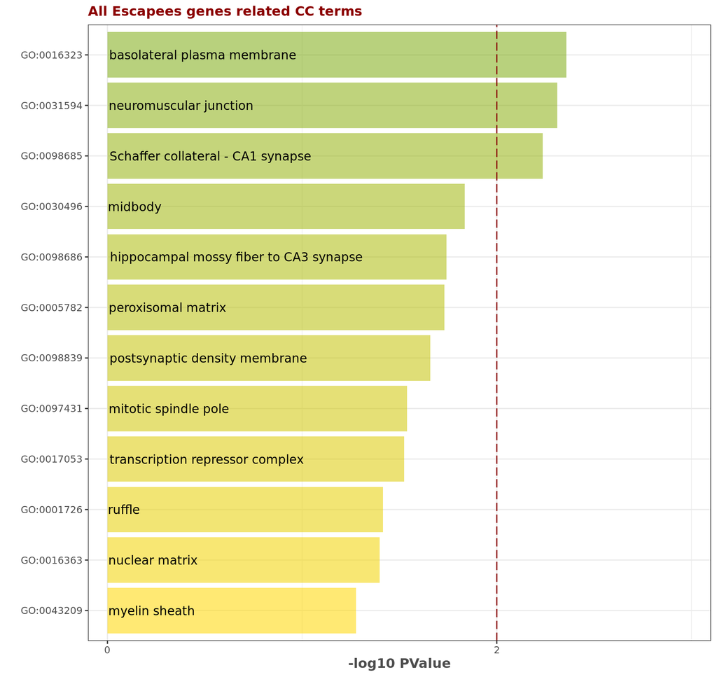

```r
if(nrow(ResCCAll$ResSel)>0){
  topGOBarplot_new(TopGORes=ResCCAll$ResSel, terms=nterms, pvalTh=0.01, plotTitle=paste0("All Escapees genes related CC terms"),
                             palette=pals$All, flip_x=FALSE)
}
```

### **Result visualization: Bubbleplot**

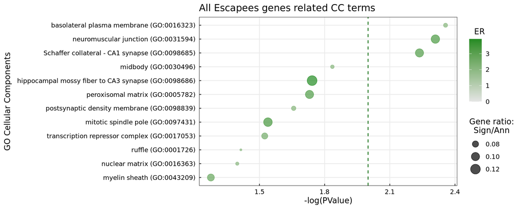

```r
if(nrow(ResCCAll$ResSel)>0){
  bubbleplot(ResCCAll$ResSel, terms=nterms, Ont = "CC", pvalTh=0.01, plotTitle="All Escapees genes related CC terms")
  }
```

### **Result visualization: table of genes in top terms**

```r
if(nrow(ResCCAll$ResSel)>0){
  table_GenesInTerm_CCAll <- TableGenesInTerm(ResCCAll$ResSel, ResCCAll$GOdata, nterms=nterms)
}

table_GenesInTerm_CCAll %>% dplyr::select(-c(Score, GOid)) %>%
    datatable(class = 'hover', rownames = FALSE, extension='Buttons', escape = FALSE, caption = paste0("All genes in top ", nterms, " CC terms"), options = list(pageLength=10, dom='Bfrtip', autoWidth=TRUE, buttons=list(c('csv', 'excel'))))
```

| Gene | GOterm |
| --- | --- |
| ABCC1 | basolateral plasma membrane (GO:0016323) |
| ADRA2A | basolateral plasma membrane (GO:0016323) |
| AJAP1 | basolateral plasma membrane (GO:0016323) |
| ATP2C2 | basolateral plasma membrane (GO:0016323) |
| C5AR1 | basolateral plasma membrane (GO:0016323) |
| CD38 | basolateral plasma membrane (GO:0016323) |
| DLG1 | basolateral plasma membrane (GO:0016323) |
| DLG2 | basolateral plasma membrane (GO:0016323) |
| FRMPD2 | basolateral plasma membrane (GO:0016323) |
| IDE | basolateral plasma membrane (GO:0016323) |

[output cut: 80 more lines]

# 5. Saving and Session Info

```r
save.image(paste0(OutputFolder, "AnnotationAndFunctionalEnv.RData"))
saveRDS(AnnotatedEscapees, paste0(OutputFolder, "AnnotatedEscapees.rds"))
```

```r
file_conn <- file(paste0(OutputFolder, "EscapeeGenes_ensembl.txt"), "w")
for (element in gsub(x = EscapeeGenes_ensembl, pattern = "\\..*", replacement = "")) {
  cat(element, "\n", file = file_conn)
}
close(file_conn)
```

```r
file_conn <- file(paste0(OutputFolder, "EscapeeGenes_symbol.txt"), "w")
for (element in EscapeeGenes_symbol) {
  cat(element, "\n", file = file_conn)
}
close(file_conn)
```

```r
file_conn <- file(paste0(OutputFolder, "GeneUniverse_symbol.txt"), "w")
for (element in GeneUniverse_symbol) {
  cat(element, "\n", file = file_conn)
}
close(file_conn)
```

```r
SessionInfo <- sessionInfo()
Date <- date()
```

```r
Date
## [1] "Thu Jul 24 15:16:52 2025"
SessionInfo
## R version 4.2.1 (2022-06-23)
## Platform: x86_64-pc-linux-gnu (64-bit)
## Running under: Ubuntu 20.04.4 LTS
##
## Matrix products: default
## BLAS:   /usr/lib/x86_64-linux-gnu/blas/libblas.so.3.9.0
## LAPACK: /usr/lib/x86_64-linux-gnu/lapack/liblapack.so.3.9.0
##
## locale:
##  [1] LC_CTYPE=en_US.UTF-8       LC_NUMERIC=C
##  [3] LC_TIME=en_US.UTF-8        LC_COLLATE=en_US.UTF-8
##  [5] LC_MONETARY=en_US.UTF-8    LC_MESSAGES=en_US.UTF-8
##  [7] LC_PAPER=en_US.UTF-8       LC_NAME=C
##  [9] LC_ADDRESS=C               LC_TELEPHONE=C
## [11] LC_MEASUREMENT=en_US.UTF-8 LC_IDENTIFICATION=C
##
## attached base packages:
## [1] stats4    stats     graphics  grDevices utils     datasets  methods
## [8] base
##
## other attached packages:
##  [1] bsseq_1.34.0                SummarizedExperiment_1.28.0
##  [3] MatrixGenerics_1.10.0       matrixStats_1.0.0
##  [5] GenomicRanges_1.50.2        GenomeInfoDb_1.34.9
##  [7] topGO_2.50.0                SparseM_1.81
##  [9] GO.db_3.16.0                graph_1.76.0
## [11] viridis_0.6.2               viridisLite_0.4.2
## [13] RColorBrewer_1.1-3          data.table_1.14.8
## [15] DT_0.28                     org.Hs.eg.db_3.16.0
## [17] AnnotationDbi_1.60.2        IRanges_2.32.0
## [19] S4Vectors_0.36.2            Biobase_2.58.0
## [21] BiocGenerics_0.44.0         ChIPseeker_1.34.1
## [23] gridExtra_2.3               scales_1.2.1
## [25] dplyr_1.1.2                 plotly_4.10.2
## [27] ggplot2_3.4.2
##
## loaded via a namespace (and not attached):
##   [1] shadowtext_0.1.2
##   [2] fastmatch_1.1-3
##   [3] BiocFileCache_2.6.1
##   [4] plyr_1.8.8
##   [5] igraph_1.5.0
##   [6] lazyeval_0.2.2
##   [7] splines_4.2.1
##   [8] crosstalk_1.2.0
##   [9] BiocParallel_1.32.6
##  [10] digest_0.6.33
##  [11] yulab.utils_0.0.6
##  [12] htmltools_0.5.5
##  [13] GOSemSim_2.24.0
##  [14] fansi_1.0.4
##  [15] magrittr_2.0.3
##  [16] memoise_2.0.1
##  [17] BSgenome_1.66.3
##  [18] limma_3.54.2
##  [19] Biostrings_2.66.0
##  [20] graphlayouts_0.8.4
##  [21] R.utils_2.12.2
##  [22] enrichplot_1.18.4
##  [23] prettyunits_1.1.1
##  [24] colorspace_2.1-0
##  [25] blob_1.2.4
##  [26] rappdirs_0.3.3
##  [27] ggrepel_0.9.3
##  [28] xfun_0.39
##  [29] crayon_1.5.2
##  [30] RCurl_1.98-1.12
##  [31] jsonlite_1.8.7
##  [32] TxDb.Hsapiens.UCSC.hg19.knownGene_3.2.2
##  [33] scatterpie_0.1.8
##  [34] ape_5.7-1
##  [35] glue_1.6.2
##  [36] polyclip_1.10-4
##  [37] gtable_0.3.3
##  [38] zlibbioc_1.44.0
##  [39] XVector_0.38.0
##  [40] DelayedArray_0.24.0
##  [41] Rhdf5lib_1.20.0
##  [42] HDF5Array_1.26.0
##  [43] DOSE_3.24.2
##  [44] DBI_1.1.3
##  [45] Rcpp_1.0.11
##  [46] plotrix_3.8-2
##  [47] progress_1.2.2
##  [48] gridGraphics_0.5-1
##  [49] tidytree_0.4.2
##  [50] bit_4.0.5
##  [51] htmlwidgets_1.6.2
##  [52] httr_1.4.6
##  [53] fgsea_1.24.0
##  [54] gplots_3.1.3
##  [55] ellipsis_0.3.2
##  [56] R.methodsS3_1.8.2
##  [57] pkgconfig_2.0.3
##  [58] XML_3.99-0.14
##  [59] farver_2.1.1
##  [60] sass_0.4.7
##  [61] dbplyr_2.3.3
##  [62] locfit_1.5-9.7
##  [63] utf8_1.2.3
##  [64] labeling_0.4.2
##  [65] ggplotify_0.1.0
##  [66] tidyselect_1.2.0
##  [67] rlang_1.1.1
##  [68] reshape2_1.4.4
##  [69] munsell_0.5.0
##  [70] tools_4.2.1
##  [71] cachem_1.0.8
##  [72] cli_3.6.1
##  [73] generics_0.1.3
##  [74] RSQLite_2.3.1
##  [75] evaluate_0.21
##  [76] stringr_1.5.0
##  [77] fastmap_1.1.1
##  [78] yaml_2.3.7
##  [79] ggtree_3.6.2
##  [80] knitr_1.43
##  [81] bit64_4.0.5
##  [82] tidygraph_1.2.3
##  [83] caTools_1.18.2
##  [84] purrr_1.0.1
##  [85] KEGGREST_1.38.0
##  [86] ggraph_2.1.0
##  [87] sparseMatrixStats_1.10.0
##  [88] nlme_3.1-162
##  [89] R.oo_1.25.0
##  [90] aplot_0.1.10
##  [91] xml2_1.3.5
##  [92] biomaRt_2.54.1
##  [93] compiler_4.2.1
##  [94] rstudioapi_0.15.0
##  [95] filelock_1.0.2
##  [96] curl_5.0.1
##  [97] png_0.1-8
##  [98] treeio_1.23.1
##  [99] tibble_3.2.1
## [100] tweenr_2.0.2
## [101] bslib_0.5.0
## [102] stringi_1.7.12
## [103] highr_0.10
## [104] GenomicFeatures_1.50.4
## [105] lattice_0.21-8
## [106] Matrix_1.6-0
## [107] permute_0.9-7
## [108] vctrs_0.6.3
## [109] rhdf5filters_1.10.1
## [110] pillar_1.9.0
## [111] lifecycle_1.0.3
## [112] jquerylib_0.1.4
## [113] cowplot_1.1.1
## [114] bitops_1.0-7
## [115] patchwork_1.1.2
## [116] rtracklayer_1.58.0
## [117] qvalue_2.30.0
## [118] R6_2.5.1
## [119] BiocIO_1.8.0
## [120] KernSmooth_2.23-22
## [121] codetools_0.2-19
## [122] gtools_3.9.4
## [123] boot_1.3-28.1
## [124] MASS_7.3-60
## [125] rhdf5_2.42.1
## [126] rjson_0.2.21
## [127] withr_2.5.0
## [128] GenomicAlignments_1.34.1
## [129] Rsamtools_2.14.0
## [130] GenomeInfoDbData_1.2.9
## [131] parallel_4.2.1
## [132] hms_1.1.3
## [133] grid_4.2.1
## [134] ggfun_0.0.9
## [135] tidyr_1.3.0
## [136] HDO.db_0.99.1
## [137] DelayedMatrixStats_1.20.0
## [138] rmarkdown_2.23
## [139] ggforce_0.4.1
## [140] restfulr_0.0.15
```